# Part 2

Kevin Gilmore

2/9/2020

## Create Binary Responses & Identify Important Factors

### Step 1

```r
long.landing <- ifelse(filtered$distance > 2500, 1, 0)
risky.landing <- ifelse(filtered$distance > 3000, 1, 0)
filtered_2 <- cbind(filtered[-8], long.landing, risky.landing)
```

Two new binary variables are created and the data for “distance” is eliminated.

### Step 2

Below is a histogram for distribution of long.landing.

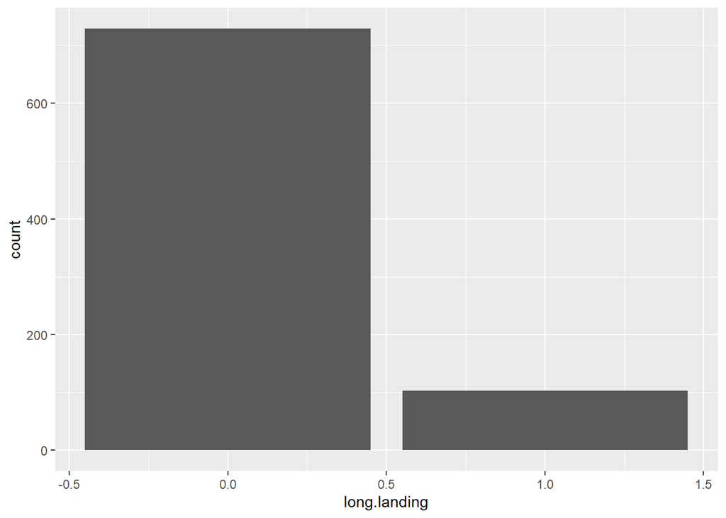

```r
ggplot(filtered_2,aes(x=long.landing)) + geom_bar()
```

### Step 3

```r
variables <- c("aircraft", "duration","no_pasg" ,"speed_ground", "speed_air" ,"height" ,"pitch", "risky.landing")
coefficient <- rep(NA,length(variables))
p_values <- rep(NA,length(variables))

fitted <- data.frame(variables,coefficient,p_values)

for (i in seq_along(variables))
{
  fitted$coefficient[i] <- summary(glm(filtered_2$long.landing ~  filtered_2[[variables[i]]],family=binomial))$coefficients[,1][2]
  fitted$p_values[i] <- summary(glm(filtered_2$long.landing ~  filtered_2[[variables[i]]],family=binomial))$coefficients[,4][2]
  }

single_factor_table <- fitted %>%
  mutate(Odds_ratio= exp(coefficient)) %>%
  mutate(Direction = ifelse(coefficient >0,'Positive','Negative'))%>%
  arrange(p_values)
single_factor_table
```

```
##       variables  coefficient     p_values   Odds_ratio Direction
## 1  speed_ground  0.472345755 3.935329e-14 1.603752e+00  Positive
## 2     speed_air  0.512321765 4.334124e-11 1.669162e+00  Positive
## 3      aircraft  0.860999732 8.894411e-05 2.365524e+00  Positive
## 4         pitch  0.401253005 4.635611e-02 1.493695e+00  Positive
## 5        height  0.008661495 4.200538e-01 1.008699e+00  Positive
## 6       no_pasg -0.007334497 6.021288e-01 9.926923e-01  Negative
## 7      duration -0.001070492 6.305122e-01 9.989301e-01  Negative
## 8 risky.landing 21.420072621 9.795377e-01 2.007333e+09  Positive
```

Based on the results; ground speed, air speed, aircraft, and pitch are seen as significant factors.

### Step 4

Below are the assocations of significant factors with “long.landing.”

Ground speed

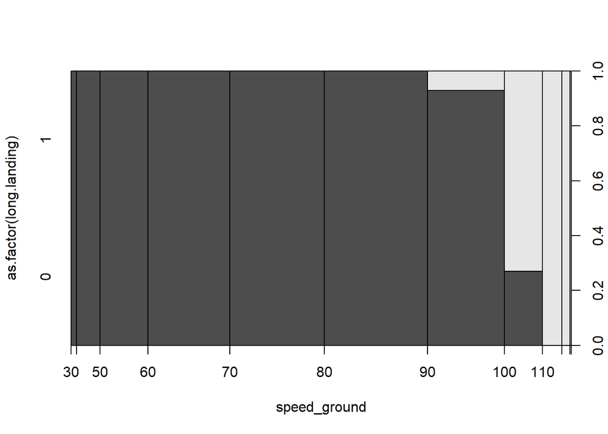

```r
plot(as.factor(long.landing)~ speed_ground,data = filtered_2)
```

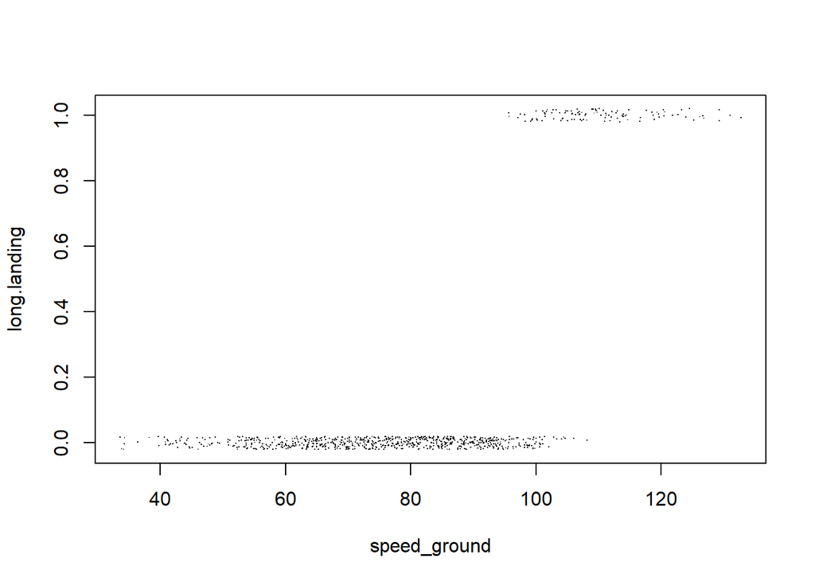

```r
plot(jitter(long.landing,0.1)~jitter(speed_ground),filtered_2,xlab="speed_ground",
     ylab="long.landing",pch=".")
```

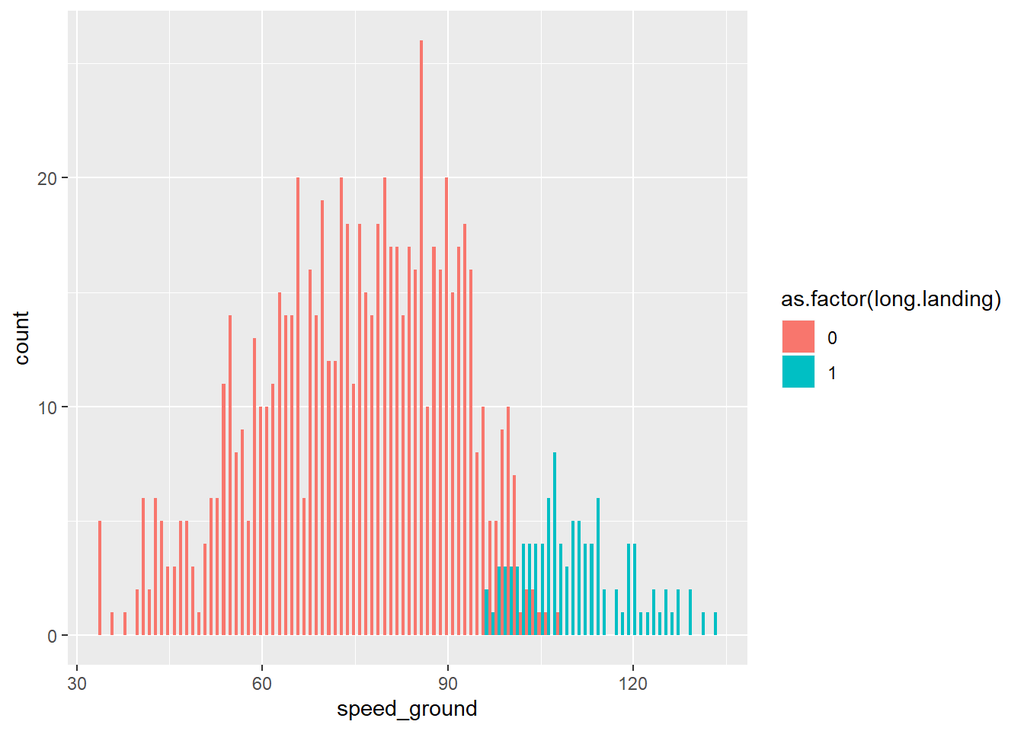

```r
ggplot(filtered_2,aes(x=speed_ground,fill=as.factor(long.landing)))+
  geom_histogram(position="dodge",binwidth = 1)
```

Air Speed

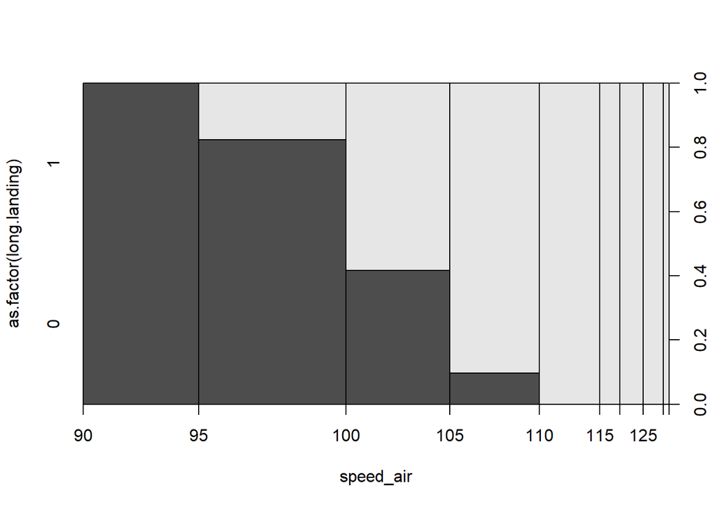

```r
plot(as.factor(long.landing)~ speed_air,data = filtered_2)
```

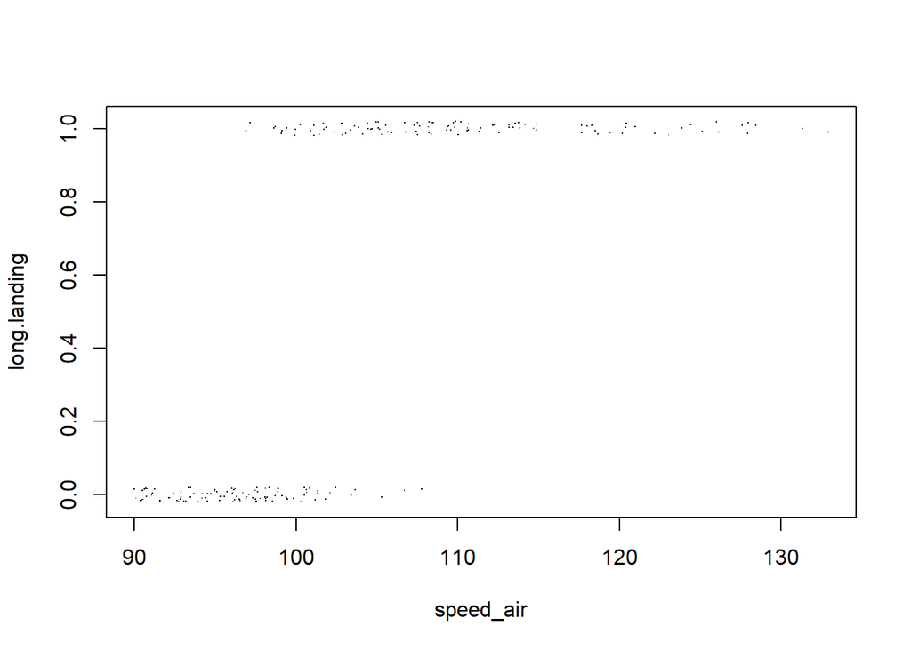

```r
plot(jitter(long.landing,0.1)~jitter(speed_air),filtered_2,xlab="speed_air",
     ylab="long.landing",pch=".")
```

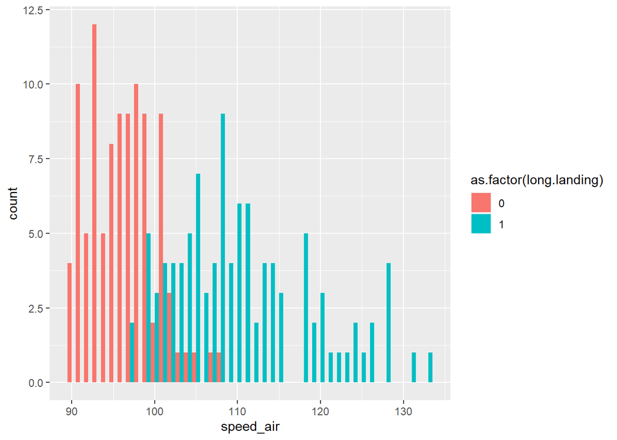

```r
ggplot(filtered_2,aes(x=speed_air,fill=as.factor(long.landing)))+
  geom_histogram(position="dodge",binwidth = 1)
```

Aircraft

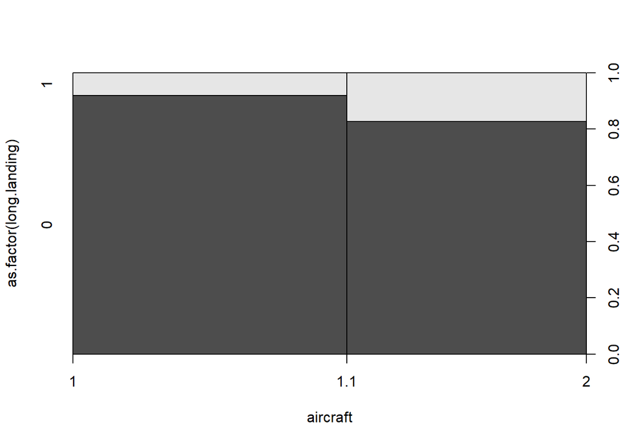

```r
plot(as.factor(long.landing)~ aircraft,data = filtered_2)
```

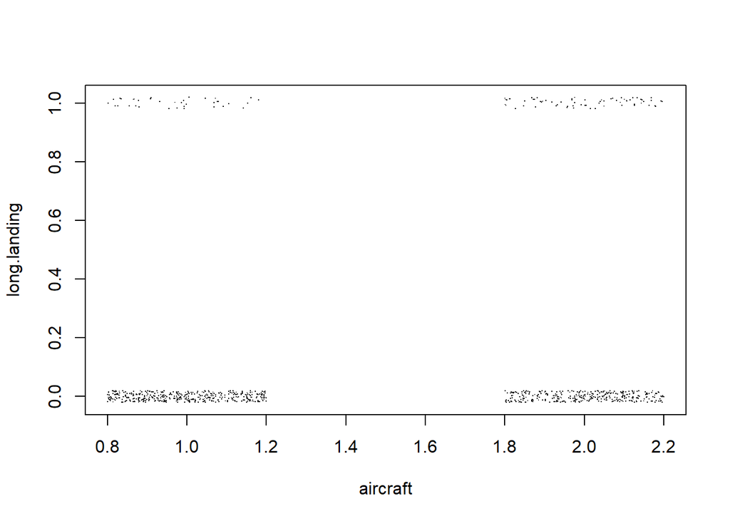

```r
plot(jitter(long.landing,0.1)~jitter(aircraft),filtered_2,xlab="aircraft",
     ylab="long.landing",pch=".")
```

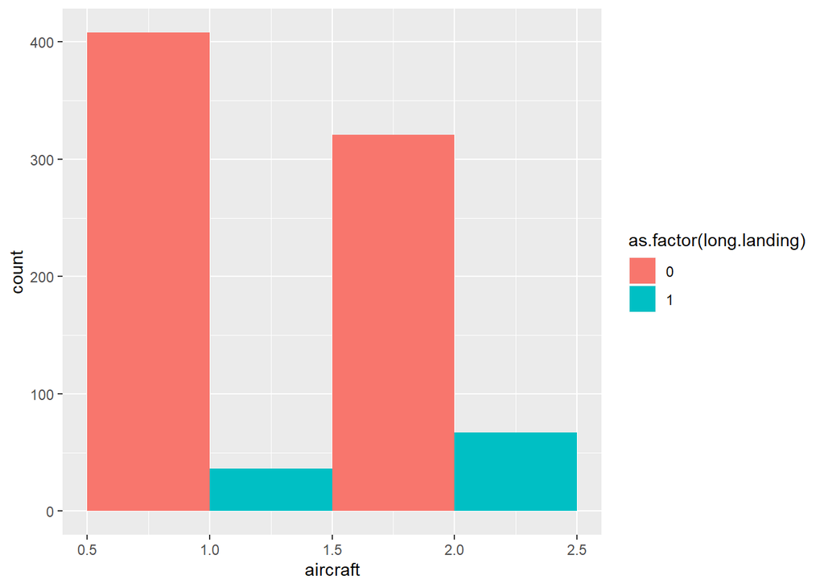

```r
ggplot(filtered_2,aes(x=aircraft,fill=as.factor(long.landing)))+
  geom_histogram(position="dodge",binwidth = 1)
```

Pitch

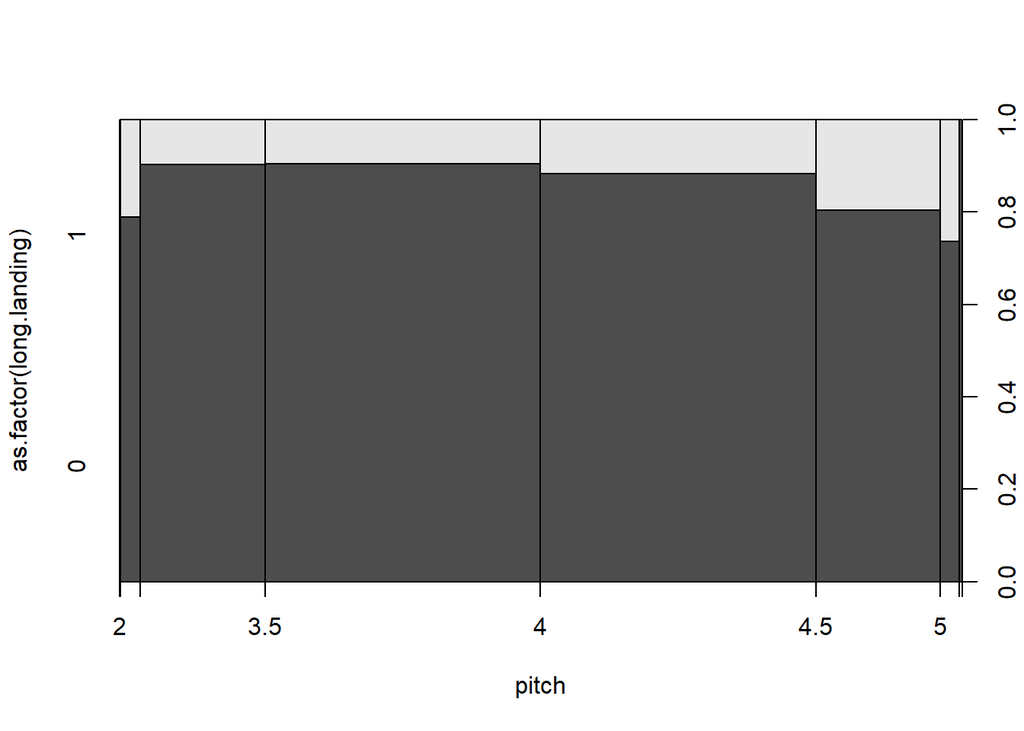

```r
plot(as.factor(long.landing)~ pitch,data = filtered_2)
```

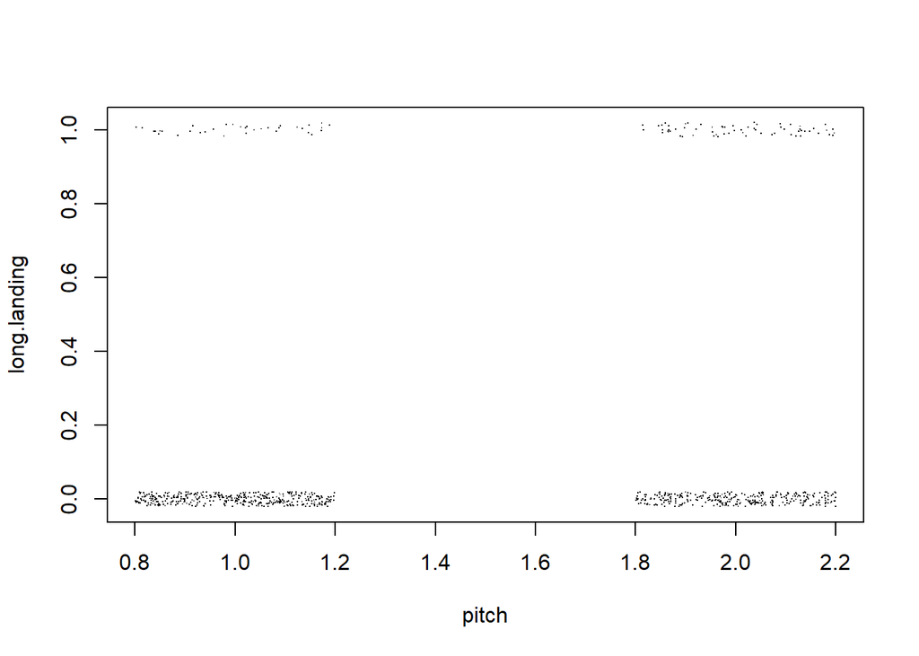

```r
plot(jitter(long.landing,0.1)~jitter(aircraft),filtered_2,xlab="pitch",
     ylab="long.landing",pch=".")
```

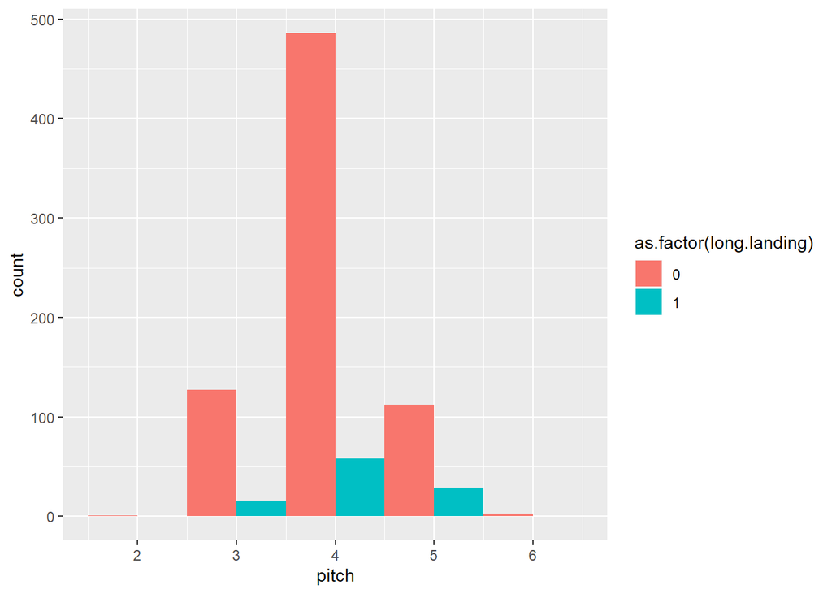

```r
ggplot(filtered_2,aes(x=pitch,fill=as.factor(long.landing)))+
  geom_histogram(position="dodge",binwidth = 1)
```

### Step 5

Air speed is removed because there are over 600 missing values. The full model contains the significant factors of ground speed, aircraft, and pitch in relation to long.landing.

```r
full_model <- glm(long.landing ~ speed_ground + aircraft + pitch,
                  family = binomial,data = filtered_2)
summary(full_model)
```

```
##
## Call:
## glm(formula = long.landing ~ speed_ground + aircraft + pitch,
##     family = binomial, data = filtered_2)
##
## Deviance Residuals:
##      Min        1Q    Median        3Q       Max
## -2.11589  -0.01114  -0.00026   0.00000   2.40741
##
## Coefficients:
##               Estimate Std. Error z value Pr(>|z|)
## (Intercept)  -70.97203   10.88816  -6.518 7.11e-11 ***
## speed_ground   0.61471    0.09184   6.694 2.18e-11 ***
## aircraft       3.04348    0.73345   4.150 3.33e-05 ***
## pitch          1.06599    0.60389   1.765   0.0775 .
## ---
## Signif. codes:  0 '***' 0.001 '**' 0.01 '*' 0.05 '.' 0.1 ' ' 1
##
## (Dispersion parameter for binomial family taken to be 1)
##
##     Null deviance: 623.043  on 831  degrees of freedom
## Residual deviance:  81.309  on 828  degrees of freedom
## AIC: 89.309
##
## Number of Fisher Scoring iterations: 10
```

### Step 6

```r
step_f <- glm(long.landing~ aircraft+ duration + no_pasg + speed_ground + speed_air + height + pitch, data = filtered_2, family= "binomial")
model_aic <- step(step_f,trace = 0,direction = "forward")
summary(model_aic)
```

```
##
## Call:
## glm(formula = long.landing ~ aircraft + duration + no_pasg +
##     speed_ground + speed_air + height + pitch, family = "binomial",
##     data = filtered_2)
##
## Deviance Residuals:
##      Min        1Q    Median        3Q       Max
## -2.48853  -0.01367   0.00000   0.00047   1.56917
##
## Coefficients:
##                Estimate Std. Error z value Pr(>|z|)
## (Intercept)  -2.051e+02  5.852e+01  -3.506 0.000455 ***
## aircraft      8.784e+00  2.623e+00   3.349 0.000811 ***
## duration      3.031e-04  1.048e-02   0.029 0.976919
## no_pasg      -7.359e-02  7.009e-02  -1.050 0.293744
## speed_ground -2.255e-01  3.845e-01  -0.587 0.557471
## speed_air     1.985e+00  7.080e-01   2.804 0.005051 **
## height        4.226e-01  1.429e-01   2.956 0.003116 **
## pitch         1.469e+00  1.055e+00   1.392 0.163818
## ---
## Signif. codes:  0 '***' 0.001 '**' 0.01 '*' 0.05 '.' 0.1 ' ' 1
##
## (Dispersion parameter for binomial family taken to be 1)
##
##     Null deviance: 270.199  on 194  degrees of freedom
## Residual deviance:  32.909  on 187  degrees of freedom
##   (637 observations deleted due to missingness)
## AIC: 48.909
##
## Number of Fisher Scoring iterations: 10
```

This model is different from the table obtained in step 3.In this model, aircraft, speed_air, and height are seen as significant.

### Step 7

```r
model_bic <- step(step_f, trace = 0,direction = "forward",criterion = "BIC")
summary(model_bic)
```

```
##
## Call:
## glm(formula = long.landing ~ aircraft + duration + no_pasg +
##     speed_ground + speed_air + height + pitch, family = "binomial",
##     data = filtered_2)
##
## Deviance Residuals:
##      Min        1Q    Median        3Q       Max
## -2.48853  -0.01367   0.00000   0.00047   1.56917
##
## Coefficients:
##                Estimate Std. Error z value Pr(>|z|)
## (Intercept)  -2.051e+02  5.852e+01  -3.506 0.000455 ***
## aircraft      8.784e+00  2.623e+00   3.349 0.000811 ***
## duration      3.031e-04  1.048e-02   0.029 0.976919
## no_pasg      -7.359e-02  7.009e-02  -1.050 0.293744
## speed_ground -2.255e-01  3.845e-01  -0.587 0.557471
## speed_air     1.985e+00  7.080e-01   2.804 0.005051 **
## height        4.226e-01  1.429e-01   2.956 0.003116 **
## pitch         1.469e+00  1.055e+00   1.392 0.163818
## ---
## Signif. codes:  0 '***' 0.001 '**' 0.01 '*' 0.05 '.' 0.1 ' ' 1
##
## (Dispersion parameter for binomial family taken to be 1)
##
##     Null deviance: 270.199  on 194  degrees of freedom
## Residual deviance:  32.909  on 187  degrees of freedom
##   (637 observations deleted due to missingness)
## AIC: 48.909
##
## Number of Fisher Scoring iterations: 10
```

The results are the same as that in the previous step, as height is also seen as significant, altough it is not in step 3.

### Step 8

The model I would select will include ground speed, aircraft, and height. Below is the full model and histograms with this specific variables.

```r
selected_model <- glm(long.landing ~ speed_ground + aircraft + height, family = binomial,
                      data = filtered_2)
summary(selected_model)
```

```
##
## Call:
## glm(formula = long.landing ~ speed_ground + aircraft + height,
##     family = binomial, data = filtered_2)
##
## Deviance Residuals:
##      Min        1Q    Median        3Q       Max
## -2.43442  -0.00116   0.00000   0.00000   2.57435
##
## Coefficients:
##                Estimate Std. Error z value Pr(>|z|)
## (Intercept)  -108.00250   20.13151  -5.365 8.10e-08 ***
## speed_ground    0.92657    0.17242   5.374 7.70e-08 ***
## aircraft        5.04813    1.11520   4.527 5.99e-06 ***
## height          0.23106    0.05959   3.877 0.000106 ***
## ---
## Signif. codes:  0 '***' 0.001 '**' 0.01 '*' 0.05 '.' 0.1 ' ' 1
##
## (Dispersion parameter for binomial family taken to be 1)
##
##     Null deviance: 623.043  on 831  degrees of freedom
## Residual deviance:  57.047  on 828  degrees of freedom
## AIC: 65.047
##
## Number of Fisher Scoring iterations: 11
```

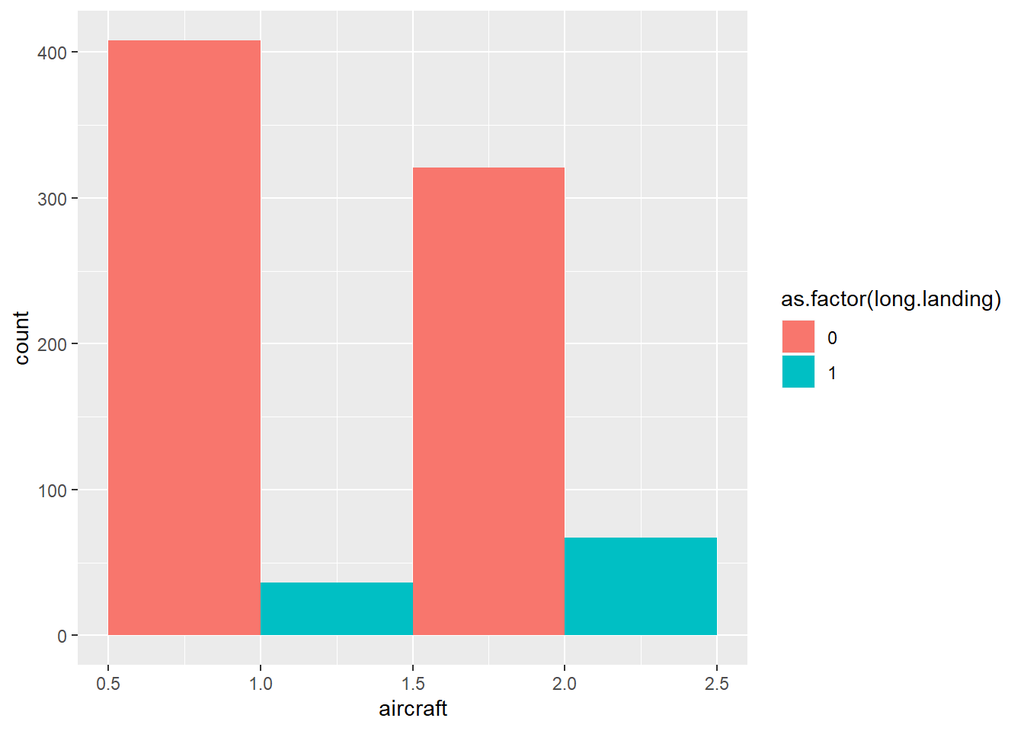

```r
ggplot(filtered_2,aes(x=aircraft,fill=as.factor(long.landing)))+
  geom_histogram(position="dodge",binwidth = 1)
```

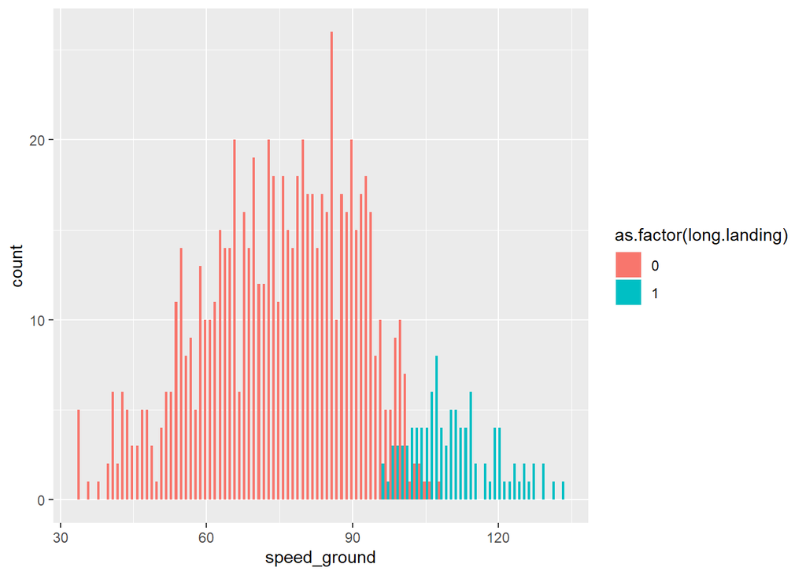

```r
ggplot(filtered_2,aes(x=speed_ground,fill=as.factor(long.landing)))+
  geom_histogram(position="dodge",binwidth = 1)
```

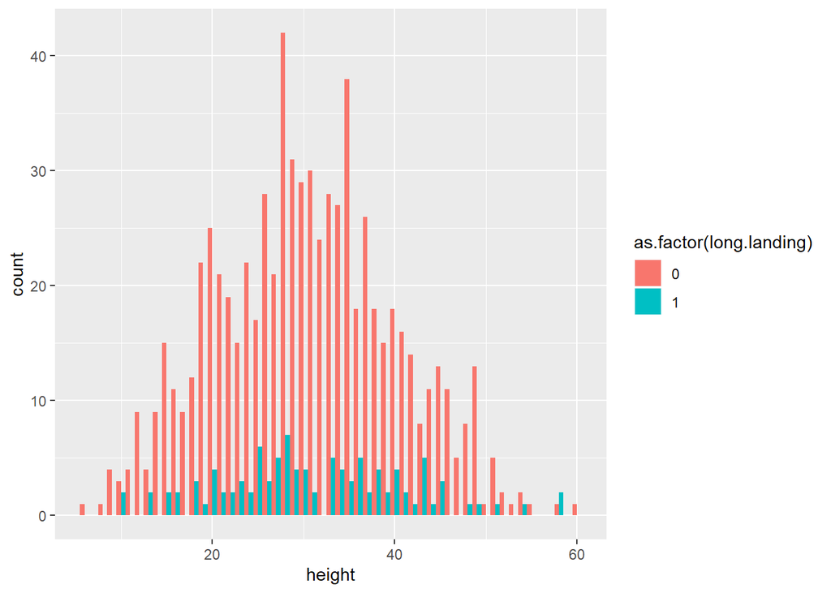

```r
ggplot(filtered_2,aes(x=height,fill=as.factor(long.landing)))+
  geom_histogram(position="dodge",binwidth = 1)
```

- If I met with a FAA agent I would try to stay away from raw numbers and show figures of the risk factors.
- The chances of long landing are higher in a Boeing
- There are only 103 instances of long landing, and 729 without a long landing
- Once AIC and BIC were examined, it became clear that height was a significant factor
- High ground speed results in long landing distance, which could be a huge risk

## Risky Landing

### Step 9

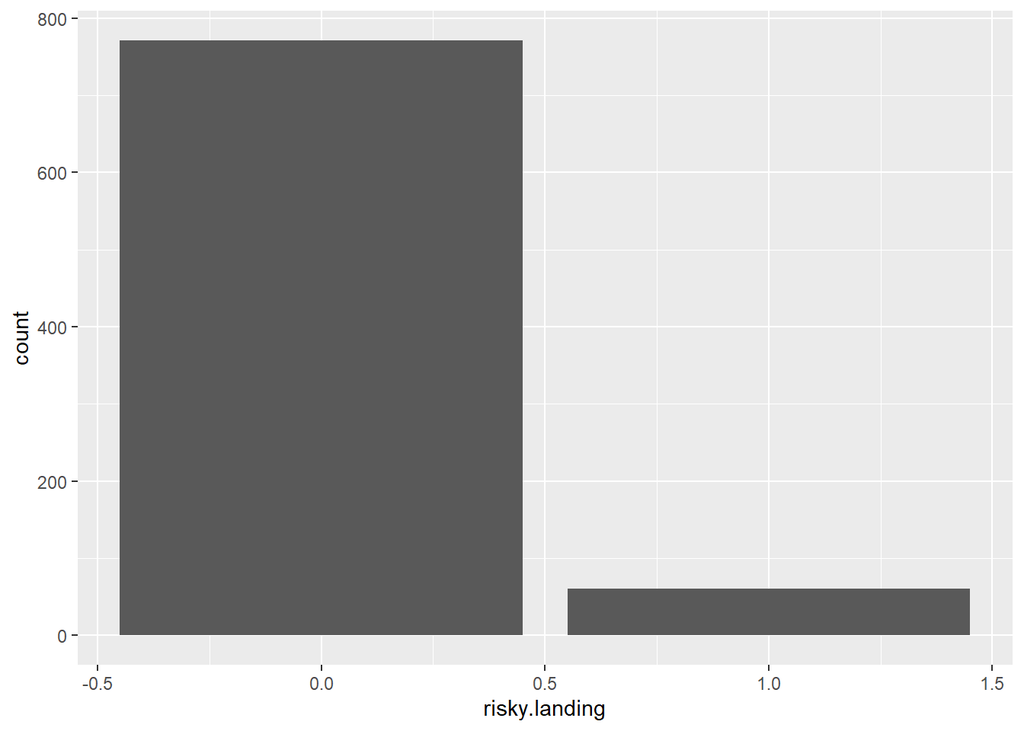

```r
ggplot(filtered_2,aes(x=risky.landing)) + geom_bar()
```

```r
fitted_risky <- data.frame(variables,coefficient,p_values)

for (i in seq_along(variables))
{
  fitted_risky$coefficient[i] <- summary(glm(filtered_2$risky.landing ~  filtered_2[[variables[i]]],family=binomial))$coefficients[,1][2]
  fitted_risky$p_values[i] <- summary(glm(filtered_2$risky.landing ~  filtered_2[[variables[i]]],family=binomial))$coefficients[,4][2]
}

single_factor_table_risky <- fitted_risky %>%
  mutate(Odds_ratio= exp(coefficient)) %>%
  mutate(Direction = ifelse(coefficient >0,'Positive','Negative'))%>%
  arrange(p_values)
single_factor_table_risky
```

```
##       variables  coefficient     p_values   Odds_ratio Direction
## 1  speed_ground  0.614218747 6.897994e-08 1.848212e+00  Positive
## 2     speed_air  0.870401900 3.728032e-06 2.387870e+00  Positive
## 3      aircraft  0.998880972 4.733996e-04 2.715242e+00  Positive
## 4         pitch  0.371773979 1.427375e-01 1.450305e+00  Positive
## 5       no_pasg -0.025468021 1.523329e-01 9.748536e-01  Negative
## 6      duration -0.001151836 6.801987e-01 9.988488e-01  Negative
## 7        height -0.002193042 8.721356e-01 9.978094e-01  Negative
## 8 risky.landing 53.132132924 9.991050e-01 1.188481e+23  Positive
```

Ground speed

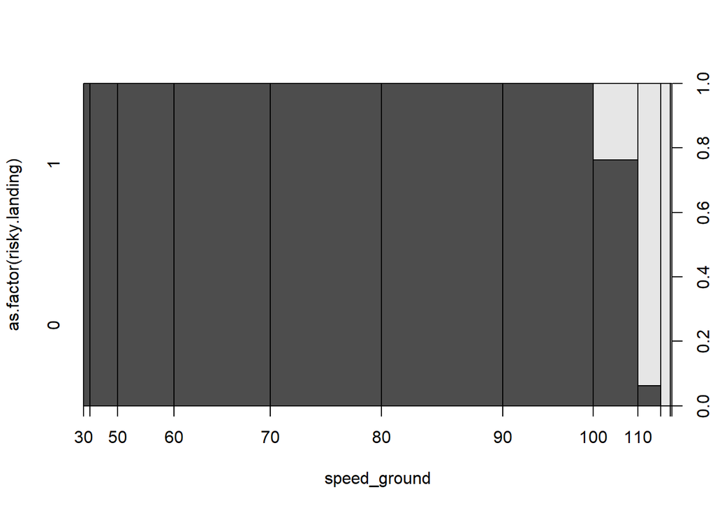

```r
plot(as.factor(risky.landing)~ speed_ground,data = filtered_2)
```

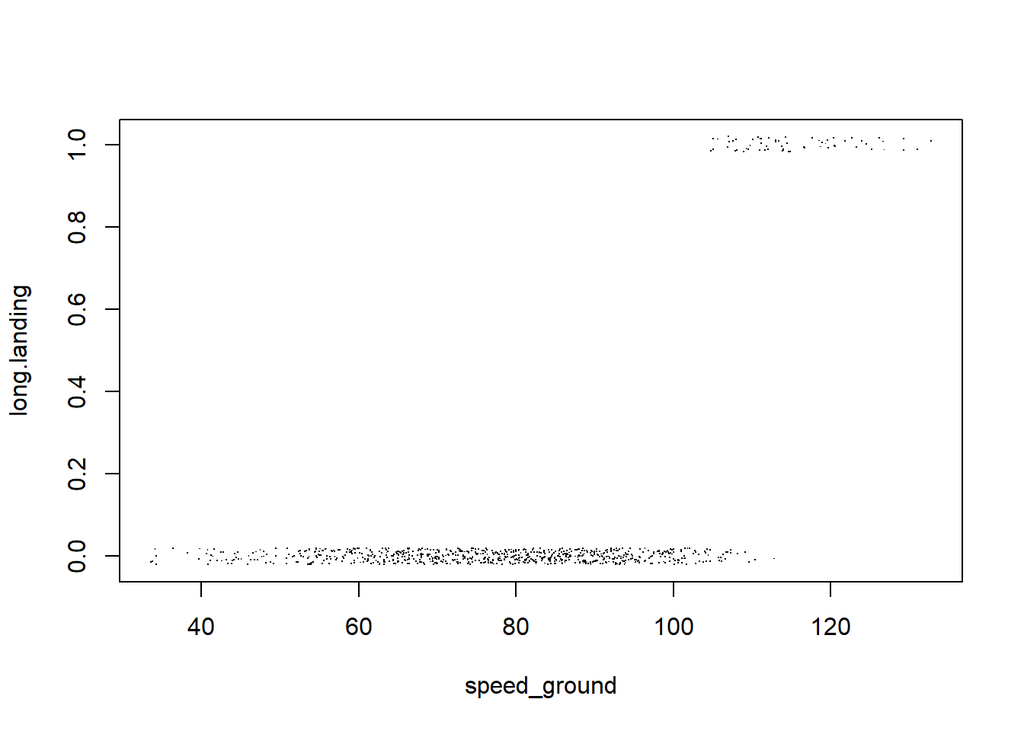

```r
plot(jitter(risky.landing,0.1)~jitter(speed_ground),filtered_2,xlab="speed_ground",
     ylab="long.landing",pch=".")
```

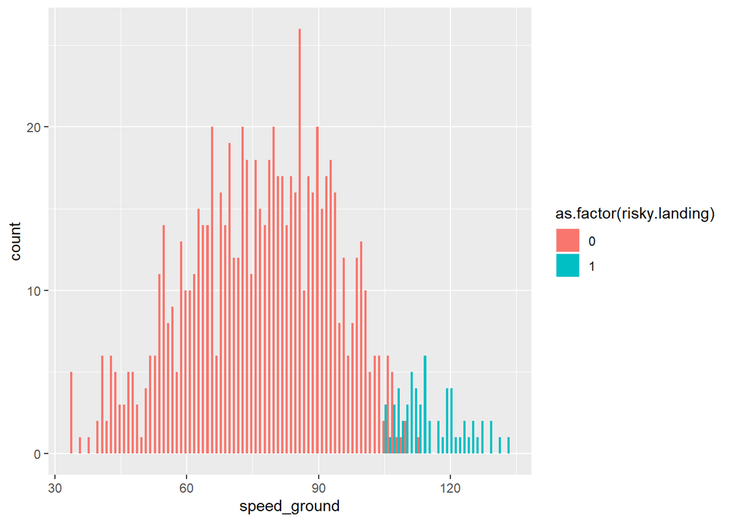

```r
ggplot(filtered_2,aes(x=speed_ground,fill=as.factor(risky.landing)))+
  geom_histogram(position="dodge",binwidth = 1)
```

Air Speed

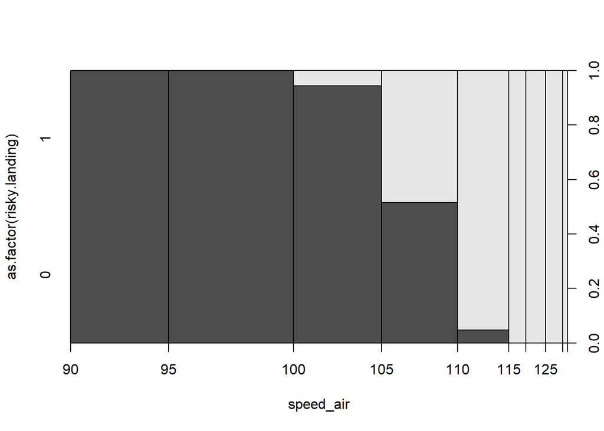

```r
plot(as.factor(risky.landing)~ speed_air,data = filtered_2)
```

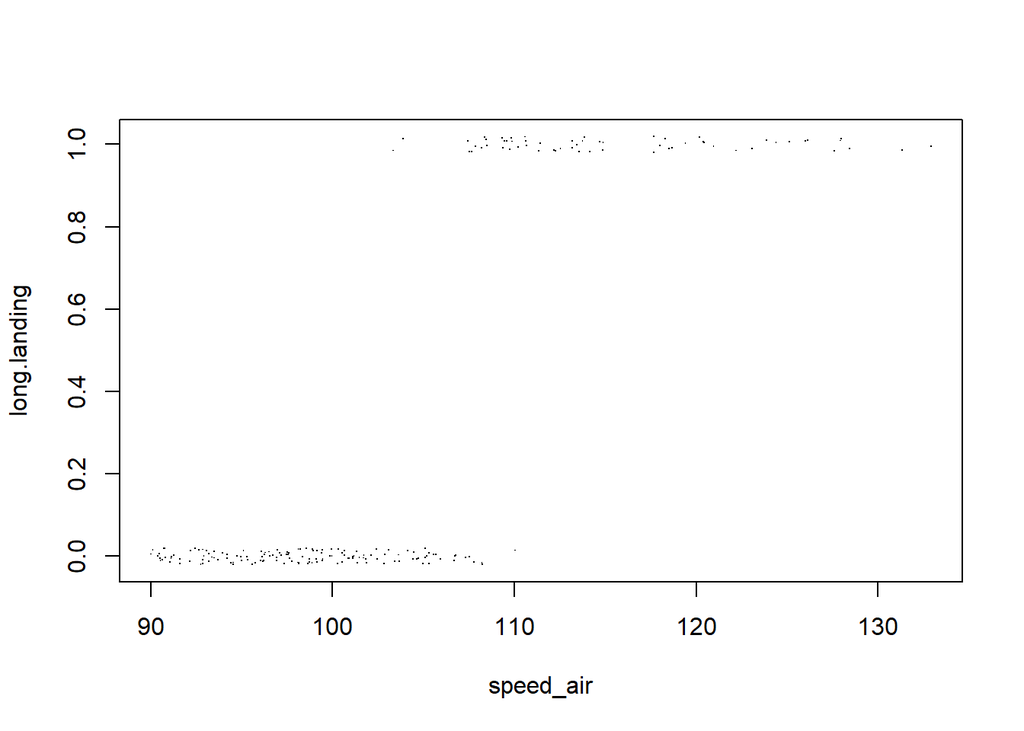

```r
plot(jitter(risky.landing,0.1)~jitter(speed_air),filtered_2,xlab="speed_air",
     ylab="long.landing",pch=".")
```

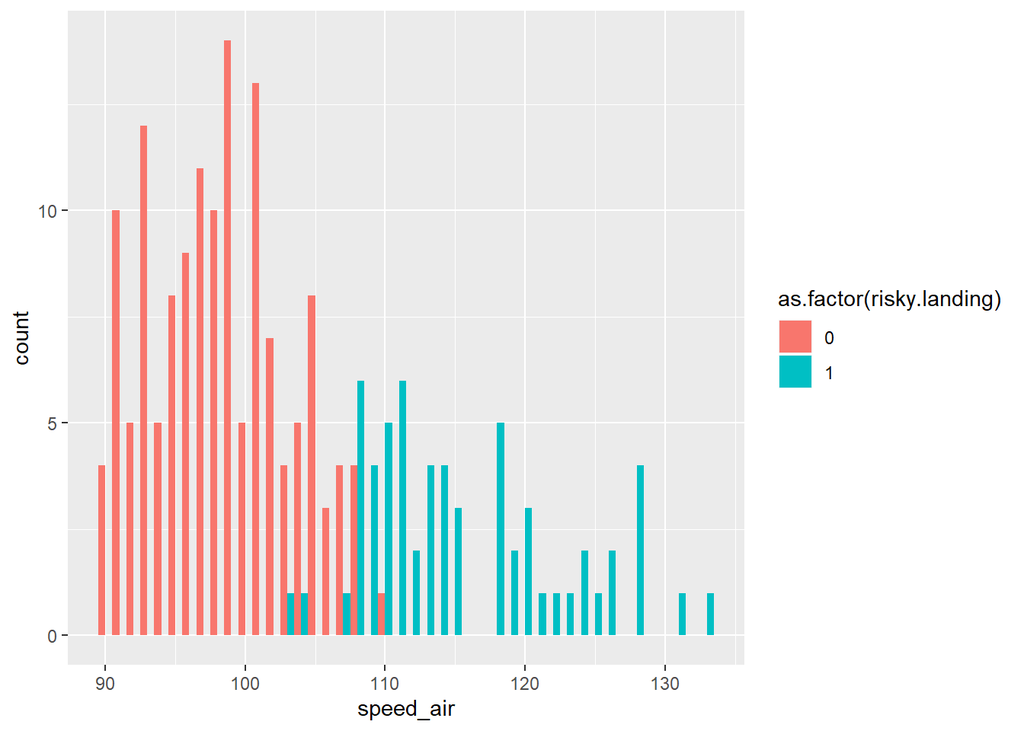

```r
ggplot(filtered_2,aes(x=speed_air,fill=as.factor(risky.landing)))+
  geom_histogram(position="dodge",binwidth = 1)
```

Aircraft

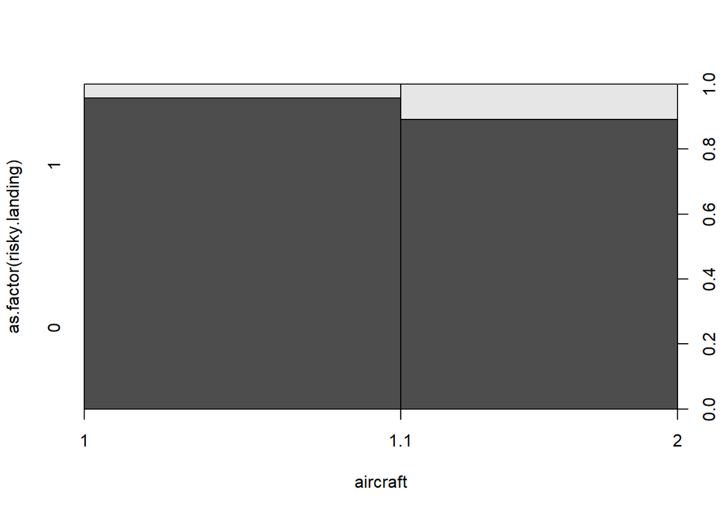

```r
plot(as.factor(risky.landing)~ aircraft,data = filtered_2)
```

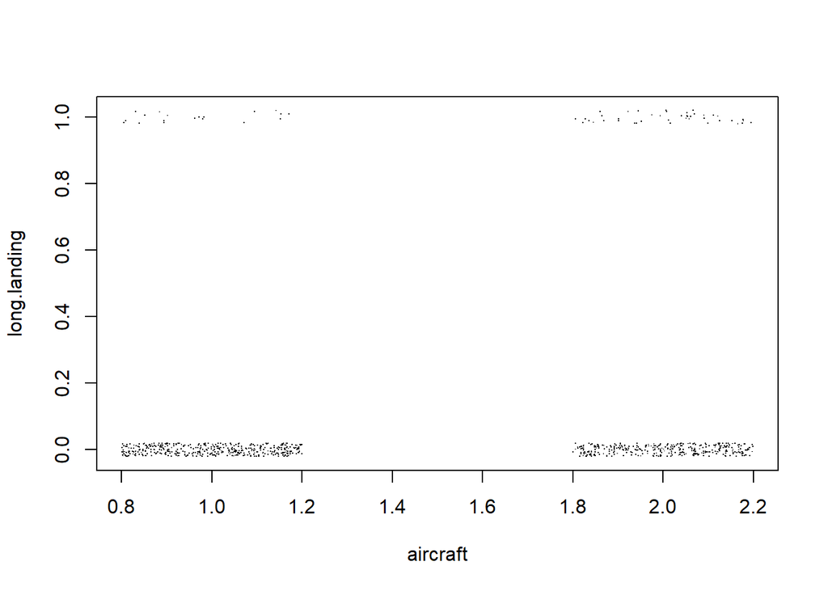

```r
plot(jitter(risky.landing,0.1)~jitter(aircraft),filtered_2,xlab="aircraft",
     ylab="long.landing",pch=".")
```

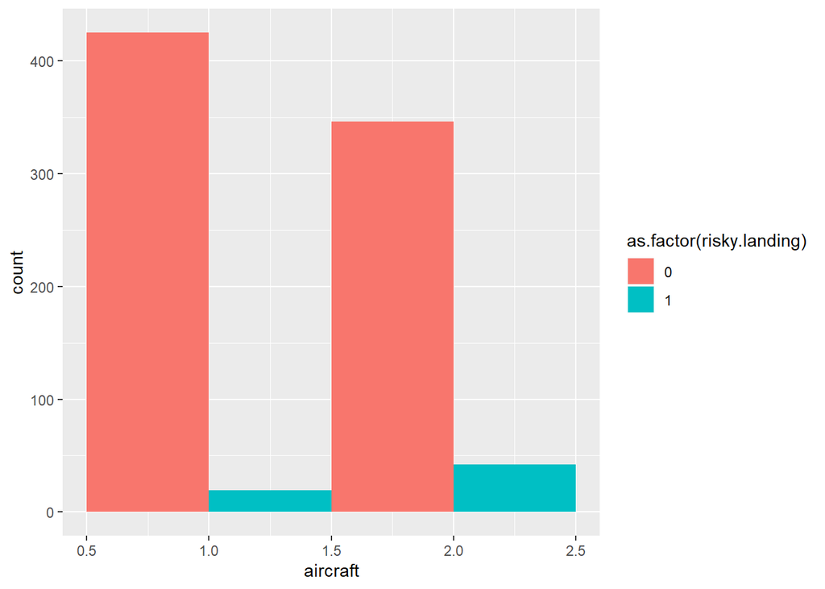

```r
ggplot(filtered_2,aes(x=aircraft,fill=as.factor(risky.landing)))+
  geom_histogram(position="dodge",binwidth = 1)
```

Pitch

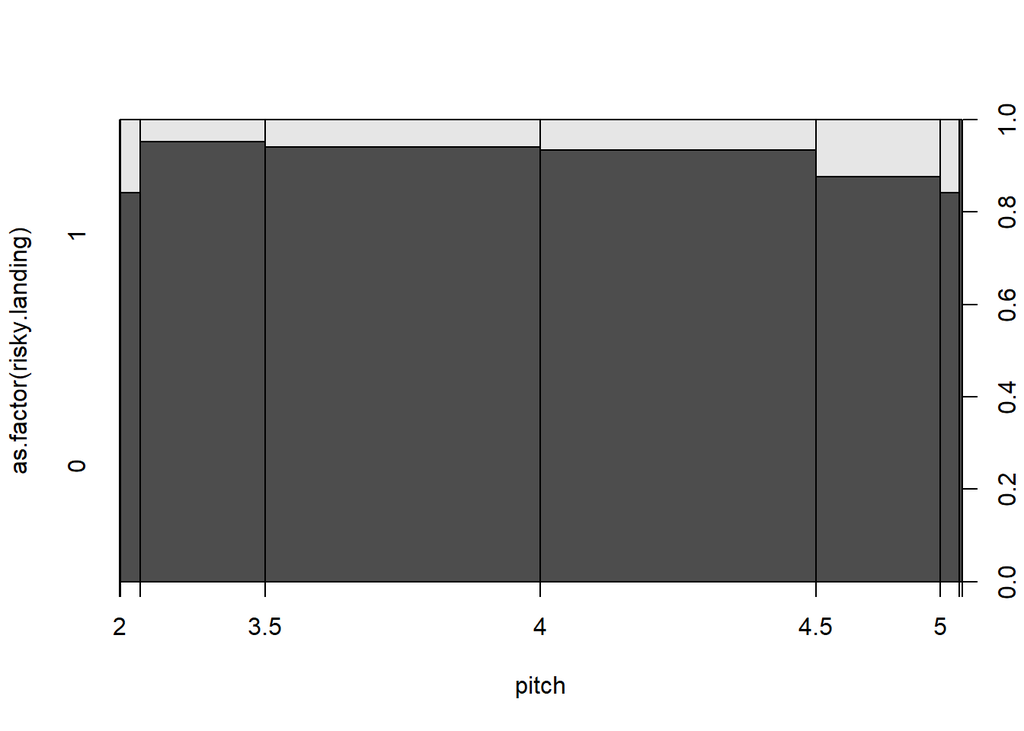

```r
plot(as.factor(risky.landing)~ pitch,data = filtered_2)
```

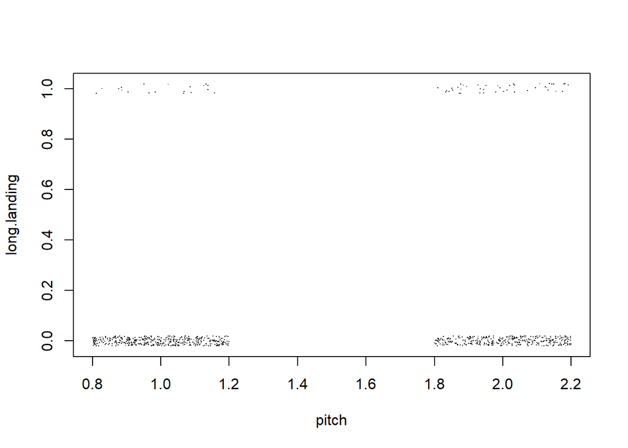

```r
plot(jitter(risky.landing,0.1)~jitter(aircraft),filtered_2,xlab="pitch",
     ylab="long.landing",pch=".")
```

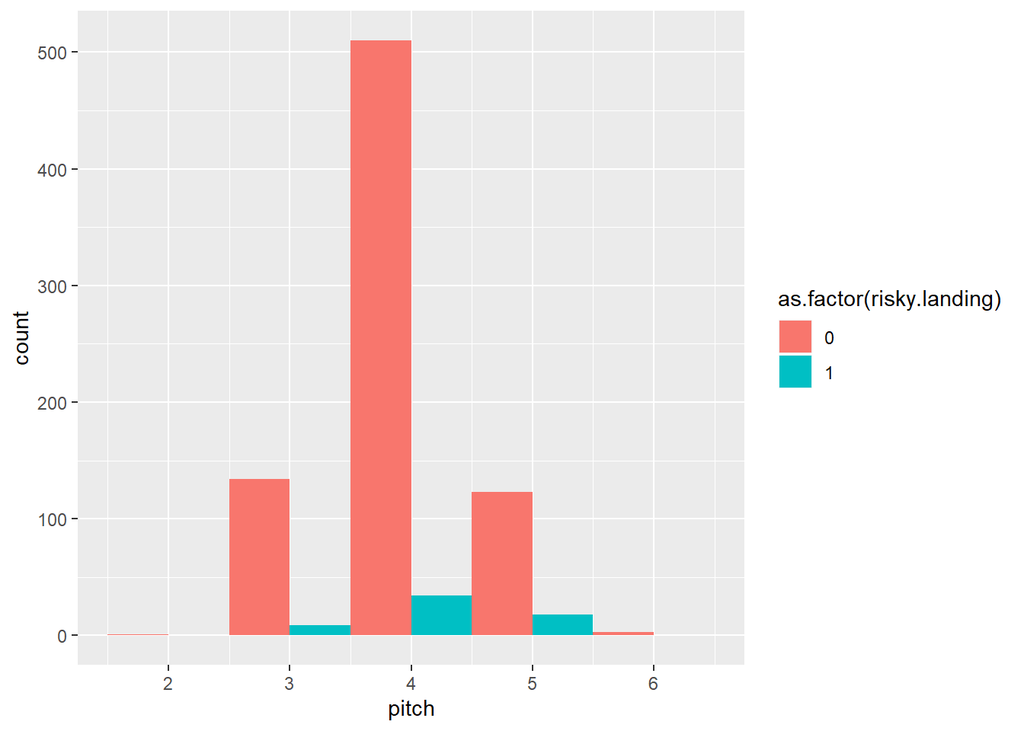

```r
ggplot(filtered_2,aes(x=pitch,fill=as.factor(risky.landing)))+
  geom_histogram(position="dodge",binwidth = 1)
```

Risky Full Model

```r
full_model_2 <- glm(risky.landing ~ speed_ground + aircraft,
                  family = binomial,data = filtered_2)
summary(full_model_2)
```

```
##
## Call:
## glm(formula = risky.landing ~ speed_ground + aircraft, family = binomial,
##     data = filtered_2)
##
## Deviance Residuals:
##      Min        1Q    Median        3Q       Max
## -2.24398  -0.00011   0.00000   0.00000   1.61021
##
## Coefficients:
##               Estimate Std. Error z value Pr(>|z|)
## (Intercept)  -106.0963    25.7459  -4.121 3.77e-05 ***
## speed_ground    0.9263     0.2248   4.121 3.78e-05 ***
## aircraft        4.0190     1.2494   3.217   0.0013 **
## ---
## Signif. codes:  0 '***' 0.001 '**' 0.01 '*' 0.05 '.' 0.1 ' ' 1
##
## (Dispersion parameter for binomial family taken to be 1)
##
##     Null deviance: 436.195  on 831  degrees of freedom
## Residual deviance:  40.097  on 829  degrees of freedom
## AIC: 46.097
##
## Number of Fisher Scoring iterations: 12
```

Forward

```r
step_f_risky <- glm(risky.landing~ aircraft+ duration + no_pasg + speed_ground + speed_air + height + pitch,
              data = filtered_2, family= "binomial")
model_aic_risky <- step(step_f_risky,trace = 0,direction = "forward")
summary(model_aic_risky)
```

```
##
## Call:
## glm(formula = risky.landing ~ aircraft + duration + no_pasg +
##     speed_ground + speed_air + height + pitch, family = "binomial",
##     data = filtered_2)
##
## Deviance Residuals:
##      Min        1Q    Median        3Q       Max
## -1.95653  -0.00291  -0.00017   0.00001   2.23576
##
## Coefficients:
##                Estimate Std. Error z value Pr(>|z|)
## (Intercept)  -156.74968   50.67835  -3.093  0.00198 **
## aircraft        7.33037    3.00197   2.442  0.01461 *
## duration        0.00198    0.01587   0.125  0.90070
## no_pasg        -0.12011    0.09589  -1.253  0.21034
## speed_ground   -0.16366    0.49825  -0.328  0.74256
## speed_air       1.61745    0.65439   2.472  0.01345 *
## height          0.04535    0.05768   0.786  0.43179
## pitch          -1.31605    1.42985  -0.920  0.35736
## ---
## Signif. codes:  0 '***' 0.001 '**' 0.01 '*' 0.05 '.' 0.1 ' ' 1
##
## (Dispersion parameter for binomial family taken to be 1)
##
##     Null deviance: 240.724  on 194  degrees of freedom
## Residual deviance:  22.144  on 187  degrees of freedom
##   (637 observations deleted due to missingness)
## AIC: 38.144
##
## Number of Fisher Scoring iterations: 10
```

BIC

```r
model_bic_risky <- step(step_f_risky, trace = 0,direction = "forward",criterion = "BIC")
summary(model_bic_risky)
```

```
##
## Call:
## glm(formula = risky.landing ~ aircraft + duration + no_pasg +
##     speed_ground + speed_air + height + pitch, family = "binomial",
##     data = filtered_2)
##
## Deviance Residuals:
##      Min        1Q    Median        3Q       Max
## -1.95653  -0.00291  -0.00017   0.00001   2.23576
##
## Coefficients:
##                Estimate Std. Error z value Pr(>|z|)
## (Intercept)  -156.74968   50.67835  -3.093  0.00198 **
## aircraft        7.33037    3.00197   2.442  0.01461 *
## duration        0.00198    0.01587   0.125  0.90070
## no_pasg        -0.12011    0.09589  -1.253  0.21034
## speed_ground   -0.16366    0.49825  -0.328  0.74256
## speed_air       1.61745    0.65439   2.472  0.01345 *
## height          0.04535    0.05768   0.786  0.43179
## pitch          -1.31605    1.42985  -0.920  0.35736
## ---
## Signif. codes:  0 '***' 0.001 '**' 0.01 '*' 0.05 '.' 0.1 ' ' 1
##
## (Dispersion parameter for binomial family taken to be 1)
##
##     Null deviance: 240.724  on 194  degrees of freedom
## Residual deviance:  22.144  on 187  degrees of freedom
##   (637 observations deleted due to missingness)
## AIC: 38.144
##
## Number of Fisher Scoring iterations: 10
```

The results in the AIC and BIC are the same for risky.landing.

### Step 10

The best model for risky.landing contains ground speed and aircraft.

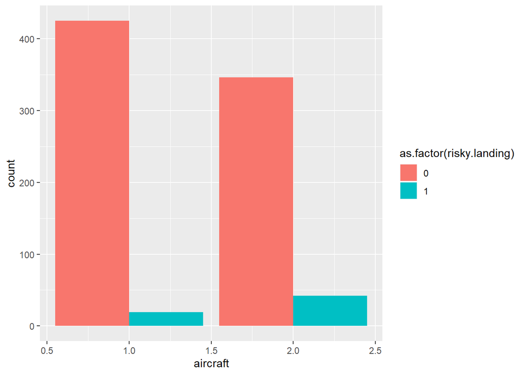

```r
full_model_2 <- glm(risky.landing ~ speed_ground + aircraft,
                    family = binomial,data = filtered_2)

ggplot(filtered_2,aes(x=aircraft,fill=as.factor(risky.landing)))+
  geom_bar(position="dodge")
```

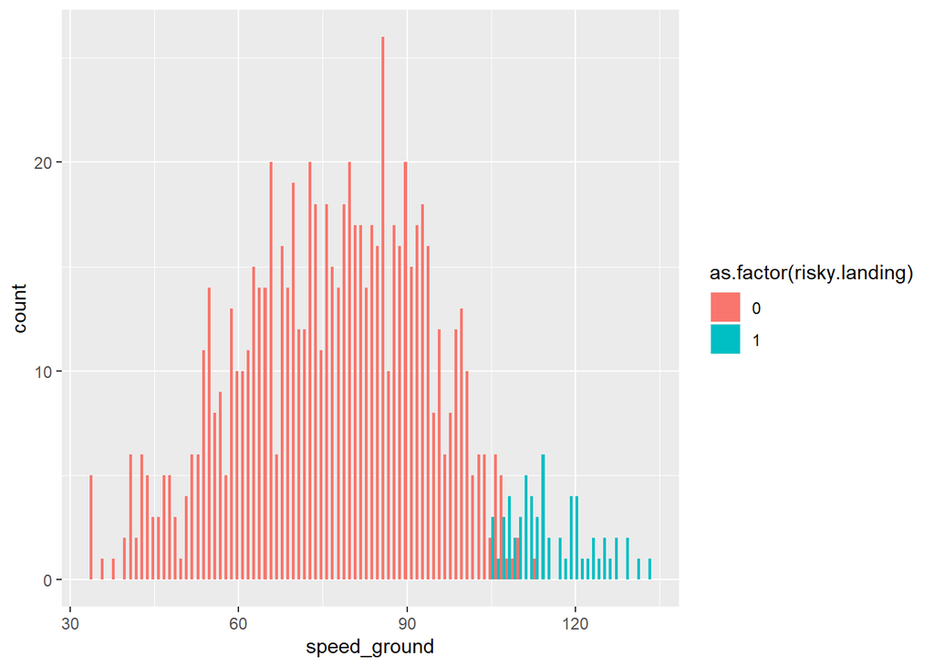

```r
ggplot(filtered_2,aes(x=speed_ground,fill=as.factor(risky.landing)))+
  geom_histogram(position="dodge",binwidth=1)
```

```r
count(risky.landing)
```

```
##   x freq
## 1 0  771
## 2 1   61
```